# Project Final Submission Template

### Step 1a: Planning

#### Identify the information in the file your program will read

Describe (all) the information that is available. Be sure to note any surprising or unusual features. (For example, some information sources have missing data, which may be blank or flagged using values like -99, NaN, or something else.)

Our dataset contains different information of patients, where the available information for each patient includes:

- Patient ID - the ID (made up of different numbers) representing the identity of patient
- Patient Name - including both first name and last name of patient
- Age - an integer
- Gender - either Female or Male. Could be saved as an enumeration or boolean
- Hypertension - 1 representing yes while 0 representing no
- Heart Disease - 1 representing yes while 0 representing no
- Marital Status - one of: Single, Divorced, Married. Could be saved as an enumeration
- Work Type - one of: Self-employed, Never Worked, Private, Government Job. Could be saved as an enumeration
- Residence Type - one of: Rural, Urban. Could be saved as an enumeration or a boolean
- Average Glucose Level - an integer
- Body Mass Index (BMI) - an integer
- Smoking Status - one of: Non-smoker, Formerly Smoked, Currently Smokes. Could be saved as an enumeration
- Alcohol Intake - one of: Social Drinker, Never, Rarely, Frequent Drinker. Could be saved as an enumeration
- Physical Activity - one of: High, Moderate, Low. Could be saved as an enumeration
- Stroke History - 1 representing yes while 0 representing no
- Family History of Stroke - either Yes or No. Could be saved as an enumeration
- Dietary Habits - one of: Vegan, Paleo, Pescatarian, Gluten-Free, Vegetarian, Non-Vegetarian, Keto. Could be saved as an enumeration
- Stress Levels - an integer with a range of [0, 10]
- Diagnosis - either Stroke or No Stroke showing the stroke diagnosis of the patient. Could be saved as an enumeration or boolean

There are also some information about patients with unusual features available in the dataset, which includes:

- Blood Pressure Levels - represented in form of: an integer/an integer, where the first integer represents the value of high blood pressure and the second integer represents the value of low blood pressure.
- Cholesterol Levels - represented in form of: HDL: an integer, LDL: an integer. The integer of HDL represents the value of “good” cholesterol, while the integer of LDL represents the value of “bad” cholesterol.
- Symptoms - a string of descriptions of the symptoms of a patient which contains a lot of missing values.

### Step 1b: Planning

#### Brainstorm ideas for what your program will produce

#### Select the idea you will build on for subsequent steps

You must brainstorm at least three ideas for graphs or charts that your program could produce and choose the one that you'd like to work on. You can choose between a line chart, histogram, bar chart, scatterplot, or pie chart.

If you would like to change your project idea from what was described in the proposal, you will need to get permission from your project TA. This is intended to help ensure that your new project idea will meet the requirements of the project. Please see the project proposal for things to be aware of when communicating with your project TA.

The question of our project is: How does the risk of having strokes act upon age groups in Male and Female respectively? Regarding to this question, we have brainstormed three ideas for the graphs that our program could produce in our project, which are the followings:

Grouped Bar Chart:

- age groups on the x-axis
- the risk of having strokes as the length of bars on the y-axis
- grouped the bars according to the gender
- each grouped bars showing female and male respectively
- benefits of having a grouped bar graph:
  - clear representation - the bars indicating the risk of having strokes in different age groups in different genders are grouped and coloured, which allows clear and easy identification for any trends
  - direct and visual comparison - since the risk of having strokes are shown directly in the graph, we can directly compare the risk in different age groups for both genders by simply seeing the graph

Pie Charts:

- one represents the proportion of females and males who have experienced strokes in the entire dataset
- one represents the proportion of females having strokes in different age groups
- one represents the proportion of males having strokes in different age groups
- benefits of having pie charts:
  - proportional representation - pie charts could clearly show the proportion of having strokes in different age groups, in different genders by providing a quick overview of the overall distribution
- disadvantage of having pie charts:
  - limited comparative analysis - it is hard to directly compare different proportion of having strokes in different age groups and different gender from pie charts. It is also hard to compare the risk of having strokes by using pie charts

Line Graph:

- age groups on the x-axis
- the risk of having strokes as the height of lines on the y-axis (continuous line on the entire domain of x with no gaps)
- two coloured lines showing the risk of female and male respectively
- benefits of having a line graph:
  - clear trend analysis - since the data points showing the risk of having strokes are connected to form a line, the trends and changes over age groups are emphasized and highlighted, therefore could be seen directly and easily
- disadvantage of having a line graph:
  - limited comparative analysis - it cannot effectively highlight the difference in the risk of having strokes in different age groups

The grouped bar chart is chosen because it is well-suited for our specific goal of comparing the risk of strokes between males and females within different age groups. It allows for a clear, direct comparison, and it's particularly effective when dealing with categorical data like age groups.

Our program is designed to generate a grouped bar chart to visually represent the risk of having strokes in different age groups for males and females. This chart serves the purpose of answering the question: "How does the risk of strokes vary across age groups, and what are the gender-specific patterns?" The x-axis of the chart will denote different age groups, while the y-axis will represent the risk of strokes. Each age group will have two grouped and colored bars, one for females and one for males, allowing for a direct and clear comparison. As a result, 3 different types of data are needed for this graphs, which are gender, age and the stroke diagnosis of patients from our dataset.

The substantial computation involved in creating this chart goes beyond simple data reading and filtering. The program will perform percentage calculations to determine the risk of strokes in each age group for both males and females. This computation involves counting the number of individuals with strokes in each age group and dividing it by the total number of individuals in that age group, providing a nuanced understanding of the risk distribution.

Additionally, the program will ensure that the chart is visually appealing and informative by incorporating different colors for males and females, enhancing the viewer's ability to discern patterns and trends. The use of a grouped bar chart is specifically chosen for its effectiveness in comparing values across different categories, offering a comprehensive view of stroke risk variations with age and gender.

Overall, the program will produce a grouped bar chart that not only fulfills the project requirements but also involves substantial computations to derive meaningful insights into the risk of strokes in different age groups for males and females.

### Step 1c: Planning

#### Write or draw examples of what your program will produce

You must include an image that shows what your chart or plot will look like. You can insert an image using the Insert Image command near the bottom of the Edit menu.

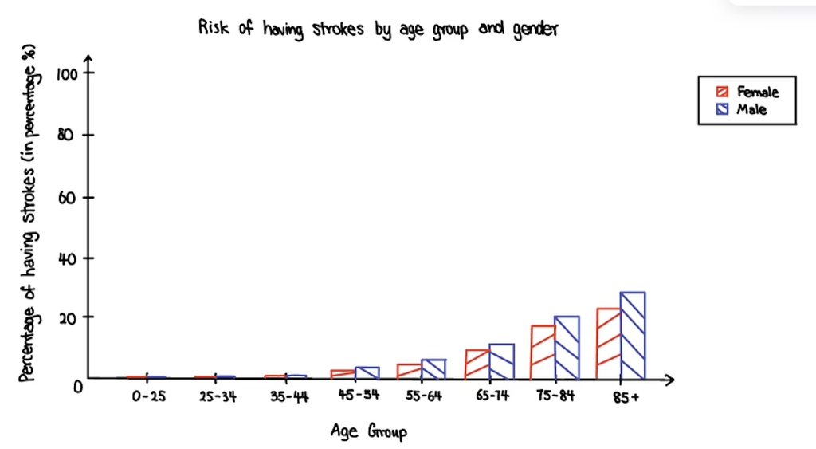

### Step 2a: Building

#### Document which information you will represent in your data definitions

Before you design data definitions in the code cell below, you must explicitly document here which information in the file you chose to represent and why that information is crucial to the chart or graph that you'll produce when you complete step 2c.

We are going to use the gender, age, and diagnosis columns in our program, which are saved in the data definition in the cell below. These three types of data are crucial for the grouped bar chart produced in step 2c. Note that there are no missing values or special types of data in those three columns in our dataset, which means that we can directly save all the data in our program without filtering out any data.

Gender is represented in the data definition, because:

- representing gender in the data definition allows us to categorize the patients according to their gender, so as to discern and compare the risk of having stroke between males and females in the grouped bar graph (where the bars indicating the risk are grouped by gender)
- we can capture any comprehensive gender-specific insights presented in the graph, identify any difference between the risk of having strokes between male and female, and understand gender-specific patterns in stroke occurrence, therefore investigate the relationship between male and female individuals across different age groups in terms of the percentage of having strokes.

Age is represented in the data definition, because:

- while focusing on the risk of having stroke across different age groups, the age of different patients are needed to be saved in our program, which allows us to categorize the patients into different age groups according to their age
- age is the factor to group patients into different age groups, which is crucial to the graph for a detailed examination of age-specific trends
- the risk of having stroke of different age groups are represented in the grouped bar graph, which allows us to discern patterns and variations in stroke risk across different stages of life

Diagnosis is represented in the data definition, because:

- the primary focus of our project is the risk of people having strokes
- the stroke diagnosis of patients are needed for the computational calculation of the risk of having strokes (dividing total number of patients being diagnosed with stroke by the total number of patients)
- data in the diagnosis column is needed to identify patients with stroke, and thus help finding the risk of having strokes across different age groups in both Male and Female

#### Design data definitions

```python
from cs103 import *
import csv
from typing import NamedTuple, List
from enum import Enum
import matplotlib.pyplot as plt
```

```python
##################
# Data Definitions

PatientData = NamedTuple("PatientData", [("gender", bool),
                                         ("age", int), # in range [0, ...)
                                         ("stroke", bool)])
# interp. information about a patient, which includes the gender of patient (True indicating Male, while
# False indicaitng Female), the age of patient (an integer in range [0, ...)), and the stroke diagonsis
# of patient (True indicating having stroke, while False indicating not having stroke)

PD0_FEMALE_NO = PatientData(False, 0, False)
PD1_MALE_NO = PatientData(True, 18, False)
PD2_MALE_YES = PatientData(True, 30, True)
PD3_MALE_NO = PatientData(True, 59, False)
PD4_MALE_YES = PatientData(True, 76, True)
PD5_FEMALE_NO = PatientData(False, 29, False)
PD6_FEMALE_YES = PatientData(False, 47, True)
PD7_FEMALE_YES = PatientData(False, 60, True)
PD8_FEMALE_NO = PatientData(False, 83, False)


# template based on Compound (2 fields) and reference rule
@typecheck
def fn_for_patient_data(pd: PatientData) -> ...:
    return ...(pd.gender, pd.age, pd.stroke)


# List[PatientData]
# interp. a list of PatientData

LOPD0 = []
LOPD1 = [PD0_FEMALE_NO]
LOPD2 = [PD1_MALE_NO, PD3_MALE_NO]
LOPD3 = [PD6_FEMALE_YES, PD7_FEMALE_YES]
LOPD4_YOUNGER_AGE = [PD0_FEMALE_NO, PD1_MALE_NO, PD5_FEMALE_NO]   # younger age: smaller than 30
LOPD5_OLDER_AGE = [PD4_MALE_YES, PD7_FEMALE_YES, PD8_FEMALE_NO]   # older age: equal to or higher than 60
LOPD8 = [PD0_FEMALE_NO, PD1_MALE_NO, PD2_MALE_YES, PD3_MALE_NO, PD4_MALE_YES,
         PD5_FEMALE_NO, PD6_FEMALE_YES, PD7_FEMALE_YES, PD8_FEMALE_NO]

@typecheck
# template based on arbitary-sized and reference rule
def fn_for_lopd(lopd: List[PatientData]) -> ...:
    # description of acc
    acc = ... # type = ...

    for pd in lopd:
        acc = ...(fn_for_patient_data(pd), acc)

    return ...(acc)
```

### Step 2b and 2c: Building

#### Design a function to read the information and store it as data in your program

#### Design functions to analyze the data

Complete these steps in the code cell below. You will likely want to rename the analyze function so that the function name describes what your analysis function does.

Unless approved by your project TA, you **cannot** use libraries such as `numpy` or `pandas`. The project is meant as a way for you to demonstrate your knowledge of the learning goals in this course. While it is convinent to use external libraries, it will do all the work and will not help us gauge your mastery of the concepts.

You also cannot use built in list functions (e.g., `sum` or `average`) when writing code to do your substantial computation. Normally we encourage you to make use of what is already available but in this case, the final project involves demonstrating skills from class (e.g., how to work with a list). Using pre-built functions for this does not enable you to demonstrate what you know.

If you wish to change your project idea, you must **first** obtain permission from your TA. When contacting your TA, please provide a valid reason for why you want to change your project. Each time you change your topic idea, your TA will have to evaluate it to see if it will meet all of the project requirements. This is non-trivial task during one of the busiest times of the semester. As such, the deadline for project idea changes will be 3 business days before the deadline. Note that the deliverable deadline will not be extended and there is no compensation for the time you spent on the previous idea.

```python
# assigning the expected result of the Read function to different variables
# in order to make the code in Read function simple and easy to read
# and can be used in the examples and tests of other helper functions

# data from "empty_test_file.csv"
EMPTY_TEST = []

# data from "single_female_test.csv"
SINGLE_FEMALE_TEST = [PatientData(False, 72, True)]

# data from "single_male_test.csv"
SINGLE_MALE_TEST = [PatientData(True, 18, False)]

# data from "all_female_test.csv"
ALL_FEMALE_TEST = [PatientData(False, 26, False),
                   PatientData(False, 25, True),
                   PatientData(False, 32, False),
                   PatientData(False, 29, False),
                   PatientData(False, 33, False),
                   PatientData(False, 61, True),
                   PatientData(False, 55, True),
                   PatientData(False, 63, False),
                   PatientData(False, 64, True),
                   PatientData(False, 59, True),
                   PatientData(False, 62, True)]

# data from "all_male_test.csv"
ALL_MALE_TEST = [PatientData(True, 18, False),
                 PatientData(True, 25, True),
                 PatientData(True, 26, True),
                 PatientData(True, 25, False),
                 PatientData(True, 33, False),
                 PatientData(True, 30, True),
                 PatientData(True, 28, False),
                 PatientData(True, 28, True),
                 PatientData(True, 86, True),
                 PatientData(True, 85, False),
                 PatientData(True, 88, True)]

# data from "genders_in_different_age_group_test.csv"
GENDERS_IN_DIFFERENT_AGE_GROUP_TEST = [PatientData(True, 80, True),
                                       PatientData(False, 42, False),
                                       PatientData(True, 82, False),
                                       PatientData(False, 40, True),
                                       PatientData(False, 40, False),
                                       PatientData(True, 83, True)]

# data from "everything_test.csv"
EVERYTHING_TEST = SINGLE_FEMALE_TEST + ALL_FEMALE_TEST + ALL_MALE_TEST + GENDERS_IN_DIFFERENT_AGE_GROUP_TEST
```

```python
###########
# Functions

# Main function
@typecheck
def main(filename: str) -> None:
    """
    Reads the file from given filename, analyzes the data, returns the result
    """
    # Template from HtDAP, based on function composition
    return display_bar_charts(read(filename))


# Read function
@typecheck
def read(filename: str) -> List[PatientData]:
    """
    Given a filename, read information from the specified file and returns a list of patient data
    """
    # return []  # stub
    # Template from HtDAP

    # lopd contains the result so far
    lopd = [] # type: List[PatientData]

    with open(filename) as csvfile:

        reader = csv.reader(csvfile)
        next(reader) # skip header line

        for row in reader:
            # you may not need to store all the rows, and you may need
            # to convert some of the strings to other types
            pd = PatientData(is_male(row[3]),
                             parse_int(row[2]),
                             have_stroke(row[-1]))
            lopd.append(pd)

    return lopd

# Helper function 1 for Read function
@typecheck
def is_male(s: str) -> bool:
    """
    Given a string, return the given string as a bool, such that:
    True indicating Male and False indicating False

    ASSUME that the given string is either "Male" or "Female"
    """
    # return False # stub
    # template from Simple Atomic
    # return ...(s)
    if s == "Male":
        return True
    elif s == "Female":
        return False

# Helper function 2 for Read function
@typecheck
def have_stroke(s: str) -> bool:
    """
    Given a string that indicates the stroke diagonsis of patient, return True if the patient has stroke,
    False otherwise

    ASSUME that the given string is the stroke diagonsis of patient, which is either "Stroke" or "No Stroke"
    """
    # return False # stub
    # template from Simple Atomic
    # return ...(s)
    if s == "Stroke":
        return True
    elif s == "No Stroke":
        return False


# Analyze function, named display_bar_chart
@typecheck
def display_bar_charts(lopd: List[PatientData]) -> None:
    """
    Given a list of patient data, display a bar chart with the risk of having strokes for both Female and Male
    side-by-side labelled age groups
    """
    # return None # stub
    # Template based on Composition

    # Step 1: create a list of the defined age groups
    x_agegroup = ["0-24", "25-34", "35-44", "45-54", "55-64", "65-74", "75-84", "85+"]

    # Step 2: create a list containg the risk of female having stroke in different age groups
    # (the y-value of the graph / the height of the bar)
    y1_female_risk = female_risk_by_age_group(lopd)

    # Step 3: create a list containg the risk of male having stroke in different age groups
    # (the y-value of the graph / the height of the bar)
    y2_male_risk = male_risk_by_age_group(lopd)

    # Step 4: plot bar graph
    plot_two_charts(y1_female_risk, y2_male_risk, x_agegroup)

    return None

# Helper function 1 for Analyze function
@typecheck
def female_risk_by_age_group(lopd: List[PatientData]) -> List[float]:
    """
    Given a list of patient data, return a list containing the risk (in percentage) of female having stroke in
    different age groups.

    The age groups are defined as the following:
    "0-24", "25-34", "35-44", "45-54", "55-64", "65-74", "75-84", "85+"
    """
    # return None # stub
    # template based on Composition

    # Step 1: find the risk of female having stroke in the age group "0-24"
    F1 = stroke_risk_by_gender_and_age_range(lopd, False, 0, 24)

    # Step 2: find the risk of female having stroke in the age group "25-34"
    F2 = stroke_risk_by_gender_and_age_range(lopd, False, 25, 34)

    # Step 3: find the risk of female having stroke in the age group "35-44"
    F3 = stroke_risk_by_gender_and_age_range(lopd, False, 35, 44)

    # Step 4: find the risk of female having stroke in the age group "45-54"
    F4 = stroke_risk_by_gender_and_age_range(lopd, False, 45, 54)

    # Step 5: find the risk of female having stroke in the age group "55-64"
    F5 = stroke_risk_by_gender_and_age_range(lopd, False, 55, 64)

    # Step 6: find the risk of female having stroke in the age group "65-74"
    F6 = stroke_risk_by_gender_and_age_range(lopd, False, 65, 74)

    # Step 7: find the risk of female having stroke in the age group "75-84"
    F7 = stroke_risk_by_gender_and_age_range(lopd, False, 75, 84)

    # Step 8: find the risk of female having stroke in the age group "85+"
    F8 = stroke_risk_by_gender_and_age_range(lopd, False, 85, 200)
    # max_age is inputed as 200 as it is impossible for people to have 200 years old

    # Step 9: create the desired list by combining the risk of female having strokes in different age group
    # found in the previous steps into a list
    female_risk = [F1, F2, F3, F4, F5, F6, F7, F8]

    # Step 10: return the list created in Step 9
    return female_risk

# Helper function 2 for Analyze function
@typecheck
def male_risk_by_age_group(lopd: List[PatientData]) -> List[float]:
    """
    Given a list of patient data, return a list containing the risk (in percentage) of male having stroke in
    different age groups.

    The age groups are defined as the following:
    "0-24", "25-34", "35-44", "45-54", "55-64", "65-74", "75-84", "85+"
    """
    # return [] # stub
    # template based on Composition

    # Step 1: find the risk of male having stroke in the age group "0-24"
    M1 = stroke_risk_by_gender_and_age_range(lopd, True, 0, 24)

    # Step 2: find the risk of male having stroke in the age group "25-34"
    M2 = stroke_risk_by_gender_and_age_range(lopd, True, 25, 34)

    # Step 3: find the risk of male having stroke in the age group "35-44"
    M3 = stroke_risk_by_gender_and_age_range(lopd, True, 35, 44)

    # Step 4: find the risk of male having stroke in the age group "45-54"
    M4 = stroke_risk_by_gender_and_age_range(lopd, True, 45, 54)

    # Step 5: find the risk of male having stroke in the age group "55-64"
    M5 = stroke_risk_by_gender_and_age_range(lopd, True, 55, 64)
```

```python
    # Step 6: find the risk of male having stroke in the age group "65-74"
    M6 = stroke_risk_by_gender_and_age_range(lopd, True, 65, 74)

    # Step 7: find the risk of male having stroke in the age group "75-84"
    M7 = stroke_risk_by_gender_and_age_range(lopd, True, 75, 84)

    # Step 8: find the risk of male having stroke in the age group "85+"
    M8 = stroke_risk_by_gender_and_age_range(lopd, True, 85, 200)
    # max_age is inputed as 200 as it is impossible for people to have 200 years old

    # Step 9: create the desired list by combining the risk of male having strokes in different age group
    # found in the previous steps into a list
    male_risk = [M1, M2, M3, M4, M5, M6, M7, M8]

    # Step 10: return the list created in Step 9
    return male_risk

# Helper functions of Helper function 1/2 for Analyze function
@typecheck
def stroke_risk_by_gender_and_age_range(lopd: List[PatientData],
                                        g: bool,
                                        min_age: int,
                                        max_age: int) -> float:
    """
    Given a list of patient data (lopd), a gender (g), a minimum value (min_age) and a maximum value (max_age)
    of age (indicating the age group), return the risk of having strokes of patients in the given gender
    and within the given age range (including the boundaries).

    Assume that the minimum value of the age (min_age) is equal to or smaller than
    the maximum value of the grant amount (max_age).
    """

    # return 0.0 # stub
    # template based on Composition

    # Step 1: filter the given list(lopd) based on the given gender(g) and age range (with the minimum value
    # (min_age) and the maximum value (max_age) inclusively of the age range)
    filtered_patients = filter_gender_and_age_range(lopd, g, min_age, max_age)

    # Step 2: find the risk of having stroke of the patients in the sublist created from Step 3 (a list
    # containing patient data with the given gender and within the given age range)
    risk_of_strokes = percentage_with_stroke(filtered_patients)

    # Step 3: return the risk of strokes of patients with the given gender and within the given age group
    return risk_of_strokes

@typecheck
def filter_gender_and_age_range(lopd: List[PatientData],
                                g: bool,
                                min_age: int,
                                max_age: int) -> List[PatientData]:
    """
    Given a list of patient data (lopd), a gender (g), a minimum value (min_age) and a maximum value (max_age)
    of age (indicating the age group), return a list of patient data with the patients
    fulfilling the following requirements:
    (a) with the given gender
    (b) with age is no less than (equals to or greater than) the given minimum value
    (c) with age is no more than (equals to or less than) the given maximum value

    Assume that the minimum value of the age (min_age) is equal to or smaller than
    the maximum value of the grant amount (max_age).
    """

    # return 0.0 # stub
    # template based on Composition

    # Step 1: find a list containing patient data with the given gender from the given list
    gender_patients = filter_gender(lopd, g)

    # Step 2: find a list containing patient data with age no less than the given minimum value from the
    # sublist created in Step 1
    above_minimum_age = patients_age_no_less_than(gender_patients, min_age)

    # Step 3: find a list containing patient data with age no more than the given maximum value from the
    # sublist created in Step 2
    within_age_range = patients_age_no_more_than(above_minimum_age, max_age)

    # Step 4: return the list of patient data containing patients with the given gender
    # and within the given age group
    return within_age_range


@typecheck
def filter_gender(lopd: List[PatientData], g: bool) -> List[PatientData]:
    """
    return a list of patient data from lopd that are with the given gender, indicated by the bool (where
    True indicating Female, and False indicating Male)
    """
    # return [] # stub
    # template from List[PatientData] with additional parameter from Simple Atomic

    # acc_patients stores patient data with the given gender seen in the list so far
    acc_patients_with_given_gender = [] # type: List[PatientData]

    for pd in lopd:
        if same_gender(pd, g):
            acc_patients_with_given_gender.append(pd)

    return acc_patients_with_given_gender

@typecheck
def same_gender(pd: PatientData, gender: bool) -> bool:
    """
    Given a patient data and a gender (a bool indicating the gender of patients, where True indicates Male
    and False indicates Female), return True if the patient from pd has the same gender (bool) with the given
    gender, False otherwise
    """
    # return False # stub
    # template from PatientData with additional parameter from Simple Atomic
    return pd.gender == gender

@typecheck
def patients_age_no_less_than(lopd: List[PatientData], min_age: int) -> List[PatientData]:
    """
    return a list of patient data from lopd where the patients' age are no less than min_age (inclusive)
    """
    # return [] # stub
    # template from List[PatientData] with additional parameter

    # acc_patients_no_less_than_min_age stores the result seen in the list so far
    acc_patients_no_less_than_min_age = [] # type: List[PatientData]

    for pd in lopd:
        if age_is_no_less_than(min_age, pd):
            acc_patients_no_less_than_min_age.append(pd)

    return acc_patients_no_less_than_min_age

@typecheck
def age_is_no_less_than(min_age: int, pd: PatientData) -> bool:
    """
    return True if pd has an age greater than or equal to a specified `min_age` and False otherwise
    """
    # return False # stub
    # template from PatientData with additional parameter
    return pd.age >= min_age

@typecheck
def patients_age_no_more_than(lopd: List[PatientData], max_age: int) -> List[PatientData]:
    """
    return a list of patient data from lopd where the patients' age are no more than max_age (inclusive)
    """
    # return [] # stub
    # template from List[PatientData] with additional parameter
```

```python
    # acc_patients_no_more_than_max_age stores the result seen in the list so far
    acc_patients_no_more_than_max_age = [] # type: List[PatientData]

    for pd in lopd:
        if age_is_no_more_than(max_age, pd):
            acc_patients_no_more_than_max_age.append(pd)

    return acc_patients_no_more_than_max_age

@typecheck
def age_is_no_more_than(max_age: int, pd: PatientData) -> bool:
    """
    return True if pd has an age less than or equal to a specified `max_age` and False otherwise
    """
    # return False # stub
    # template from PatientData with additional parameter
    return pd.age <= max_age

@typecheck
def percentage_with_stroke(lopd: List[PatientData]) -> float:
    """
    return the percentage of patients having strokes from lopd (calculated by dividing the number of patients
    with strokes by the total number of patients)

    If the given list (lopd) is empty, return 0.0
    """
    # return -1.0 # stub
    # Template from Composition

    # Step 1: find the number of patients with strokes in lopd
    having_strokes_patient_count = count_stroke_patient(lopd)

    # Step 2: find the total number of patients in lopd
    total_patient_count = count_patient(lopd)

    # Step 3: return 0.0 if the given list is empty
    if total_patient_count == 0:
        return 0.0

    # Step 4: return the percentage of patients having strokes from lopd when the given list is not empty
    else:
        return float((having_strokes_patient_count/total_patient_count)*100)

@typecheck
def count_stroke_patient(lopd: List[PatientData]) -> int:
    """
    find the number of patients with strokes from lopd
    """
    # return 0 # stub
    # template based on List[PatientData] and the reference rule
    # number_stroke_patient stores the number of patients who have stroke seen in the list so far
    number_stroke_patient = 0 # type: int

    for pd in lopd:
        if pd.stroke:
            number_stroke_patient = number_stroke_patient + 1

    return number_stroke_patient

@typecheck
def count_patient(lopd: List[PatientData]) -> int:
    """
    find the total number of patients from lopd
    """
    # return 0 # stub
    # template based on List[PatientData]
    # total_number_patient stores the number of patients seen in the list so far
    total_number_patient = 0 # type: int

    for pd in lopd:
        total_number_patient = total_number_patient + 1

    return total_number_patient

# Helper function 3 for Analyze function
@typecheck
def plot_two_charts(y1_female: List[float],
                    y2_male: List[float],
                    x_age_group: List[str]) -> None:
    """
    Plot bar chart with the risk of having strokes for both Female and Male side-by-side
    labelled by age groups

    Assumes all three list parameters are the same (non-zero) length
    """
    # return None  # stub
    # Template based on visualization

    # the width of each bar
    bar_width = 7

    # the middle coordinate for each of the bars for the first bar chart (Female groups)
    middle_of_bars_female = produce_num_sequence(y1_female, 3, (bar_width * 2) + 3)

    # the middle coordinate for each of the bars for the second bar chart (Male groups). Note that each
    # entry in the list is exactly bar_width greater than the corresponding entry in the
    # middle_of_bars_female list
    middle_of_bars_male = produce_num_sequence(y2_male, bar_width + 3, (bar_width * 2) + 3)

    # the opacity for the bars. It must be between 0 and 1, and higher numbers are more opaque (darker)
    opacity = 0.4

    # create the first bar chart
    rects1 = plt.bar(middle_of_bars_female,
                     y1_female,                # list with the height for each bar, here the risk of strokes
                     bar_width,
                     alpha = opacity,          # set the opacity
                     align = "edge",
                     color = "r",              # set the colour (here, red)
                     label = "Female")

    # create the second bar chart
    rects2 = plt.bar(middle_of_bars_male,
                     y2_male,
                     bar_width,
                     alpha = opacity,
                     align = "edge",
                     color = "b",               # notice that we use a different colour (blue)
                     label = "Male")

    # set the labels for the x-axis, y-axis, and plot title
    plt.xlabel('Age Group')
    plt.ylabel('Risk of having strokes (in percentage %)')
    plt.title('Risk of having strokes by age group and gender')

    # set the axes for our chart
    plt.axis([0,140,0,100])

    # set the labels for each 'tick' on the x-axis
    plt.xticks(middle_of_bars_male, x_age_group)

    # show the legend
    plt.legend(bbox_to_anchor = (1.05, 1), loc = 2)

    # show the plot
    plt.show()

    return None

# Helper function of Helper function 3 for Analyze function
@typecheck
def produce_num_sequence(values: List[float], initial: float, gap: float) -> List[float]:
    """
    Produce a list of numbers like [initial, initial + gap, initial + 2*gap, ...] of the same
    length as values, e.g., to give alignment coordinates for a plot. The number
    of numbers in the list is equal to len(values). The first value is initial. The gap between values
    is gap.

    E.g., [5,15,25,35,45,55,65,75] for 8 values, initial == 5, and gap == 10.
    """
    # return []  # stub
    # Template from List[float] with two additional parameters

    # nums is the numbers for the values seen so far
    nums = []  # type: List[int]

    # next_num is the next number to use
    next_num = initial

    for val in values:
        nums.append(next_num)
        next_num = next_num + gap

    return nums


### EXAMPLES AND TESTS FOR FUNCTIONS ###

# EXAMPLES AND TESTS FOR MAIN FUNCTION
# For the ASCII Art when doing the visual inspection below:
# @ incidiating the red bar (the bar showing the risk of strokes of female), while $ indicating the blue bar
# (the bar showing the risk of strokes of male)
start_testing()
```

```python
# examples and tests for main
expect(main("empty_test_file.csv"), None)
# we expect an empty chart looks similar to this:
#
#                      Risk of having strokes by age group and gender
# Risk of having strokes
#   (in percentage %)
#    100   |                                                                         @ Female
#          |                                                                         $ Male
#     80   |
#          |
#     60   |
#          |
#     40   |
#          |
#     20   |
#          |
#      0   +-----+-------+-------+-------+-------+-------+-------+------+------ Age Group
#               0-24   25-34   35-44   45-54   55-64   65-74   75-84   85+
#
expect(main("single_female_test.csv"), None)
# we expect a chart looks similar to this:
#
#                      Risk of having strokes by age group and gender
# Risk of having strokes
#   (in percentage %)
#    100   |                                             @                           @ Female
#          |                                             @                           $ Male
#     80   |                                             @
#          |                                             @
#     60   |                                             @
#          |                                             @
#     40   |                                             @
#          |                                             @
#     20   |                                             @
#          |                                             @
#      0   +-----+-------+-------+-------+-------+-------+-------+------+------ Age Group
#               0-24   25-34   35-44   45-54   55-64   65-74   75-84   85+
#
expect(main("single_male_test.csv"), None)
# we expect an empty chart looks similar to this:
#
#                      Risk of having strokes by age group and gender
# Risk of having strokes
#   (in percentage %)
#    100   |                                                                         @ Female
#          |                                                                         $ Male
#     80   |
#          |
#     60   |
#          |
#     40   |
#          |
#     20   |
#          |
#      0   +-----+-------+-------+-------+-------+-------+-------+------+------ Age Group
#               0-24   25-34   35-44   45-54   55-64   65-74   75-84   85+
#
expect(main("all_female_test.csv"), None)
# we expect a chart looks similar to this:
#
#                      Risk of having strokes by age group and gender
# Risk of having strokes
#   (in percentage %)
#    100   |                                                                         @ Female
#          |                                                                         $ Male
#     80   |                                    @
#          |                                    @
#     60   |                                    @
#          |                                    @
#     40   |                                    @
#          |                                    @
#     20   |             @                      @
#          |             @                      @
#      0   +-----+-------+-------+-------+-------+-------+-------+------+------ Age Group
#               0-24   25-34   35-44   45-54   55-64   65-74   75-84   85+
#
expect(main("all_male_test.csv"), None)
# we expect a chart looks similar to this:
#
#                      Risk of having strokes by age group and gender
# Risk of having strokes
#   (in percentage %)
#    100   |                                                                         @ Female
#          |                                                                         $ Male
#     80   |
#          |                                                             $
#     60   |              $                                              $
#          |              $                                              $
#     40   |              $                                              $
#          |              $                                              $
#     20   |              $                                              $
#          |              $                                              $
#      0   +-----+-------+-------+-------+-------+-------+-------+------+------ Age Group
#               0-24   25-34   35-44   45-54   55-64   65-74   75-84   85+
#
expect(main("genders_in_different_age_group_test.csv"), None)
# we expect a chart looks similar to this:
#
#                      Risk of having strokes by age group and gender
# Risk of having strokes
#   (in percentage %)
#    100   |                                                                         @ Female
#          |                                                                         $ Male
#     80   |
#          |                                                      $
#     60   |                                                      $
#          |                                                      $
#     40   |                                                      $
#          |                     @                                $
#     20   |                     @                                $
#          |                     @                                $
#      0   +-----+-------+-------+-------+-------+-------+-------+------+------ Age Group
#               0-24   25-34   35-44   45-54   55-64   65-74   75-84   85+
#
expect(main("everything_test.csv"), None)
# we expect a chart looks similar to this:
#
#                      Risk of having strokes by age group and gender
# Risk of having strokes
#   (in percentage %)
#    100   |                                             @                           @ Female
#          |                                             @                           $ Male
#     80   |                                     @       @
#          |                                     @       @        $      $
#     60   |              $                      @       @        $      $
#          |              $                      @       @        $      $
#     40   |              $                      @       @        $      $
#          |              $      @               @       @        $      $
#     20   |             @$      @               @       @        $      $
#          |             @$      @               @       @        $      $
#      0   +-----+-------+-------+-------+-------+-------+-------+------+------ Age Group
#               0-24   25-34   35-44   45-54   55-64   65-74   75-84   85+
#
```

```python
summary()

# EXAMPLES AND TESTS FOR READ FUNCTION
start_testing()

# examples and tests for read
expect(read("empty_test_file.csv"), EMPTY_TEST)
expect(read("single_female_test.csv"), SINGLE_FEMALE_TEST)
expect(read("single_male_test.csv"), SINGLE_MALE_TEST)
expect(read("all_female_test.csv"), ALL_FEMALE_TEST)
expect(read("all_male_test.csv"), ALL_MALE_TEST)
expect(read("genders_in_different_age_group_test.csv"), GENDERS_IN_DIFFERENT_AGE_GROUP_TEST)
expect(read("everything_test.csv"), EVERYTHING_TEST)

summary()

# EXAMPLES AND TESTS FOR HELPER FUNCTIONS OF READ FUNCTION
start_testing()

# examples and tests for is_male
expect(is_male("Male"), True)
expect(is_male("Female"), False)

summary()

start_testing()

# examples and tests for has_stroke
expect(have_stroke("Stroke"), True)
expect(have_stroke("No Stroke"), False)

summary()

# EXAMPLES AND TESTS FOR ANALYZE FUNCTION, NAMED display_two_charts
# For the ASCII Art when doing the visual inspection below:
# @ incidiating the red bar (the bar showing the risk of strokes of female), while $ indicating the blue bar
# (the bar showing the risk of strokes of male)
start_testing()

# examples and tests for display_bar_charts
expect(display_bar_charts(EMPTY_TEST), None)
# we expect an empty chart looks similar to this:
#
#                      Risk of having strokes by age group and gender
# Risk of having strokes
#   (in percentage %)
#    100   |                                                                         @ Female
#          |                                                                         $ Male
#     80   |
#          |
#     60   |
#          |
#     40   |
#          |
#     20   |
#          |
#      0   +-----+-------+-------+-------+-------+-------+-------+------+------ Age Group
#               0-24   25-34   35-44   45-54   55-64   65-74   75-84   85+
#
expect(display_bar_charts(SINGLE_FEMALE_TEST), None)
# we expect a chart looks similar to this:
#
#                      Risk of having strokes by age group and gender
# Risk of having strokes
#   (in percentage %)
#    100   |                                             @                           @ Female
#          |                                             @                           $ Male
#     80   |                                             @
#          |                                             @
#     60   |                                             @
#          |                                             @
#     40   |                                             @
#          |                                             @
#     20   |                                             @
#          |                                             @
#      0   +-----+-------+-------+-------+-------+-------+-------+------+------ Age Group
#               0-24   25-34   35-44   45-54   55-64   65-74   75-84   85+
#
expect(display_bar_charts(SINGLE_MALE_TEST), None)
# we expect an empty chart looks similar to this:
#
#                      Risk of having strokes by age group and gender
# Risk of having strokes
#   (in percentage %)
#    100   |                                                                         @ Female
#          |                                                                         $ Male
#     80   |
#          |
#     60   |
#          |
#     40   |
#          |
#     20   |
#          |
#      0   +-----+-------+-------+-------+-------+-------+-------+------+------ Age Group
#               0-24   25-34   35-44   45-54   55-64   65-74   75-84   85+
#
expect(display_bar_charts(ALL_FEMALE_TEST), None)
# we expect a chart looks similar to this:
#
#                      Risk of having strokes by age group and gender
# Risk of having strokes
#   (in percentage %)
#    100   |                                                                         @ Female
#          |                                                                         $ Male
#     80   |                                    @
#          |                                    @
#     60   |                                    @
#          |                                    @
#     40   |                                    @
#          |                                    @
#     20   |             @                      @
#          |             @                      @
#      0   +-----+-------+-------+-------+-------+-------+-------+------+------ Age Group
#               0-24   25-34   35-44   45-54   55-64   65-74   75-84   85+
#
expect(display_bar_charts(ALL_MALE_TEST), None)
# we expect a chart looks similar to this:
#
#                      Risk of having strokes by age group and gender
# Risk of having strokes
#   (in percentage %)
#    100   |                                                                         @ Female
#          |                                                                         $ Male
#     80   |
#          |                                                             $
#     60   |              $                                              $
#          |              $                                              $
#     40   |              $                                              $
#          |              $                                              $
#     20   |              $                                              $
#          |              $                                              $
#      0   +-----+-------+-------+-------+-------+-------+-------+------+------ Age Group
#               0-24   25-34   35-44   45-54   55-64   65-74   75-84   85+
#
expect(display_bar_charts(GENDERS_IN_DIFFERENT_AGE_GROUP_TEST), None)
# we expect a chart looks similar to this:
#
#                      Risk of having strokes by age group and gender
# Risk of having strokes
#   (in percentage %)
#    100   |                                                                         @ Female
#          |                                                                         $ Male
#     80   |
#          |                                                      $
#     60   |                                                      $
#          |                                                      $
#     40   |                                                      $
#          |                     @                                $
#     20   |                     @                                $
#          |                     @                                $
#      0   +-----+-------+-------+-------+-------+-------+-------+------+------ Age Group
#               0-24   25-34   35-44   45-54   55-64   65-74   75-84   85+
#
expect(display_bar_charts(EVERYTHING_TEST), None)
# we expect a chart looks similar to this:
#
#                      Risk of having strokes by age group and gender
# Risk of having strokes
#   (in percentage %)
#    100   |                                             @                           @ Female
#          |                                             @                           $ Male
#     80   |                                     @       @
#          |                                     @       @        $      $
#     60   |              $                      @       @        $      $
#          |              $                      @       @        $      $
#     40   |              $                      @       @        $      $
#          |              $      @               @       @        $      $
#     20   |             @$      @               @       @        $      $
#          |             @$      @               @       @        $      $
#      0   +-----+-------+-------+-------+-------+-------+-------+------+------ Age Group
#               0-24   25-34   35-44   45-54   55-64   65-74   75-84   85+
#
```

```python
summary()

# EXAMPLES AND TESTS FOR HELPER FUNCTIONS OF ANALYZE FUNCTION (NAMED display_two_charts)
start_testing()

# examples and tests for female_risk_by_age_group
expect(female_risk_by_age_group([]), [0.0, 0.0, 0.0, 0.0, 0.0, 0.0, 0.0, 0.0]) # empty list
expect(female_risk_by_age_group([PD5_FEMALE_NO]),
       [0.0, 0.0, 0.0, 0.0, 0.0, 0.0, 0.0, 0.0]) # list with one female without stroke
expect(female_risk_by_age_group([PD2_MALE_YES]),
       [0.0, 0.0, 0.0, 0.0, 0.0, 0.0, 0.0, 0.0]) # list with one male with stroke
expect(female_risk_by_age_group([PD5_FEMALE_NO, PD6_FEMALE_YES, PD7_FEMALE_YES, PD8_FEMALE_NO]),
       [0.0, 0.0, 0.0, 100.0, 100.0, 0.0, 0.0, 0.0])
expect(female_risk_by_age_group(ALL_FEMALE_TEST),
       [0.0, 20.0, 0.0, 0.0, (5/6 * 100), 0.0, 0.0, 0.0]) # list with all female & some with/without stroke
expect(female_risk_by_age_group(ALL_MALE_TEST),
       [0.0, 0.0, 0.0, 0.0, 0.0, 0.0, 0.0, 0.0]) # list with all male
expect(female_risk_by_age_group(GENDERS_IN_DIFFERENT_AGE_GROUP_TEST),
       [0.0, 0.0, (1/3 * 100), 0.0, 0.0, 0.0, 0.0, 0.0]) # list with some female & some with/without stroke

summary()

start_testing()

# examples and tests for male_risk_by_age_group
expect(male_risk_by_age_group([]), [0.0, 0.0, 0.0, 0.0, 0.0, 0.0, 0.0, 0.0]) # empty list
expect(male_risk_by_age_group([PD0_FEMALE_NO]), [0.0, 0.0, 0.0, 0.0, 0.0, 0.0, 0.0, 0.0]) # list without male
expect(male_risk_by_age_group([PD1_MALE_NO]),
       [0.0, 0.0, 0.0, 0.0, 0.0, 0.0, 0.0, 0.0]) # list with one male without stroke in a age group
expect(male_risk_by_age_group([PD2_MALE_YES]),
       [0.0, 100.0, 0.0, 0.0, 0.0, 0.0, 0.0, 0.0]) # list with one male with stroke in a age group
expect(male_risk_by_age_group(LOPD8),
       [0.0, 100.0, 0.0, 0.0, 0.0, 0.0, 100.0, 0.0]) # list with some males & some with/without stroke
expect(male_risk_by_age_group(ALL_FEMALE_TEST),
       [0.0, 0.0, 0.0, 0.0, 0.0, 0.0, 0.0, 0.0]) # list of females only
expect(male_risk_by_age_group(LOPD2),
       [0.0, 0.0, 0.0, 0.0, 0.0, 0.0, 0.0, 0.0]) # list of males without stroke
expect(male_risk_by_age_group(ALL_MALE_TEST),
       [0.0, (4/7)*100, 0.0, 0.0, 0.0, 0.0, 0.0, (2/3)*100]) # list of males with/without stroke
expect(male_risk_by_age_group(GENDERS_IN_DIFFERENT_AGE_GROUP_TEST),
       [0.0, 0.0, 0.0, 0.0, 0.0, 0.0, (2/3)*100, 0.0]) # list with some males & some with/without stroke

summary()

start_testing()

# examples and tests for stroke_risk_by_gender_and_age_range
expect(stroke_risk_by_gender_and_age_range([], True, 10, 92), 0.0) # empty list
expect(stroke_risk_by_gender_and_age_range(SINGLE_FEMALE_TEST, True, 32, 41),
       0.0) # single list with wrong gender and age range
expect(stroke_risk_by_gender_and_age_range(SINGLE_MALE_TEST, False, 10, 20),
       0.0) # # single list with wrong gender, correct age range
expect(stroke_risk_by_gender_and_age_range(SINGLE_MALE_TEST, True, 50, 79),
       0.0) # # single list with wrong age range, correct gender
expect(stroke_risk_by_gender_and_age_range(SINGLE_FEMALE_TEST, False, 68, 72),
       100.0) # single list with correct gender and age range (age in maximum boundaries)
expect(stroke_risk_by_gender_and_age_range([PD0_FEMALE_NO, PD5_FEMALE_NO, PD6_FEMALE_YES],
                                           False, 0, 34),
       0.0) # some with correct gender and age range & all filtered without strokes
expect(stroke_risk_by_gender_and_age_range([PD5_FEMALE_NO, PD6_FEMALE_YES, PD7_FEMALE_YES, PD8_FEMALE_NO],
                                           False, 40, 61),
       100.0) # some with correct gender and age range & all filtered having strokes
expect(stroke_risk_by_gender_and_age_range(GENDERS_IN_DIFFERENT_AGE_GROUP_TEST, False, 27, 41),
       50.0) # some with correct gender and age range
expect(stroke_risk_by_gender_and_age_range(LOPD8, True, 59, 87),
       50.0) # some with correct gender and age range (age in minimum boundaries)
expect(stroke_risk_by_gender_and_age_range(LOPD8, False, 14, 60),
       (2/3)*100) # some with correct gender and age range (age in maximum boundaries)

summary()

start_testing()

# examples and tests for filter_gender_and_age_range
expect(filter_gender_and_age_range([], True, 0, 100), []) # empty list
expect(filter_gender_and_age_range(SINGLE_FEMALE_TEST, True, 32, 41),
       []) # single list with wrong gender and age range
expect(filter_gender_and_age_range(SINGLE_MALE_TEST, False, 10, 20),
       []) # single list with wrong gender, correct age range
expect(filter_gender_and_age_range(SINGLE_MALE_TEST, True, 50, 79),
       []) # single list with wrong age range, correct gender
expect(filter_gender_and_age_range(SINGLE_FEMALE_TEST, False, 68, 72),
       SINGLE_FEMALE_TEST) # single list with correct gender and age range (age in maximum boundaries)
expect(filter_gender_and_age_range(GENDERS_IN_DIFFERENT_AGE_GROUP_TEST, False, 27, 41),
       [PatientData(False, 40, True), PatientData(False, 40, False)]) # some with correct gender and age range
expect(filter_gender_and_age_range(LOPD8, True, 59, 87),
       [PD3_MALE_NO, PD4_MALE_YES]) # some with correct gender and age range (age in minimum boundaries)
expect(filter_gender_and_age_range(LOPD8, False, 14, 60),
       [PD5_FEMALE_NO, PD6_FEMALE_YES,
        PD7_FEMALE_YES]) # some with correct gender and age range (age in maximum boundaries)

summary()

start_testing()

# examples and tests for filter_gender
expect(filter_gender([], False), []) # empty list
expect(filter_gender([], True), []) # empty list
expect(filter_gender([PD1_MALE_NO], True), [PD1_MALE_NO]) # filter none
expect(filter_gender([PD5_FEMALE_NO, PD7_FEMALE_YES], False), [PD5_FEMALE_NO, PD7_FEMALE_YES]) # filter none
expect(filter_gender([PD2_MALE_YES, PD4_MALE_YES, PD3_MALE_NO], False), []) # filter all
expect(filter_gender([PD0_FEMALE_NO, PD6_FEMALE_YES, PD8_FEMALE_NO], True), []) # filter all
expect(filter_gender([PD2_MALE_YES, PD3_MALE_NO, PD0_FEMALE_NO, PD6_FEMALE_YES, PD4_MALE_YES], True),
       [PD2_MALE_YES, PD3_MALE_NO, PD4_MALE_YES]) # filter some
```

```python
summary()

start_testing()

# examples and tests for same_gender
expect(same_gender(PD0_FEMALE_NO, True), False)
expect(same_gender(PD0_FEMALE_NO, False), True)
expect(same_gender(PD4_MALE_YES, True), True)
expect(same_gender(PD4_MALE_YES, False), False)

summary()

start_testing()

# examples and tests for patients_age_no_less_than
expect(patients_age_no_less_than([], 90), []) # empty list
expect(patients_age_no_less_than([PD1_MALE_NO], 18), [PD1_MALE_NO]) # filter none (equal case)
expect(patients_age_no_less_than([PD3_MALE_NO, PD4_MALE_YES, PD6_FEMALE_YES, PD8_FEMALE_NO], 33),
       [PD3_MALE_NO, PD4_MALE_YES, PD6_FEMALE_YES, PD8_FEMALE_NO]) # filter none
expect(patients_age_no_less_than([PD6_FEMALE_YES], 53), []) # filter all
expect(patients_age_no_less_than([PD2_MALE_YES, PD3_MALE_NO, PD5_FEMALE_NO, PD6_FEMALE_YES], 67),
       []) # filter all
expect(patients_age_no_less_than([PD0_FEMALE_NO, PD1_MALE_NO, PD4_MALE_YES, PD7_FEMALE_YES], 42),
       [PD4_MALE_YES, PD7_FEMALE_YES]) # filter some
expect(patients_age_no_less_than([PD1_MALE_NO, PD4_MALE_YES, PD5_FEMALE_NO, PD8_FEMALE_NO], 76),
       [PD4_MALE_YES, PD8_FEMALE_NO]) # filter some (including equal case)

summary()

start_testing()

# examples and tests for age_is_no_less_than
expect(age_is_no_less_than(43, PD7_FEMALE_YES), True) # larger case
expect(age_is_no_less_than(51, PD3_MALE_NO), True) # larger case
expect(age_is_no_less_than(18, PD1_MALE_NO), True) # equal case
expect(age_is_no_less_than(60, PD7_FEMALE_YES), True) # equal case
expect(age_is_no_less_than(47, PD2_MALE_YES), False) # smaller case

summary()

start_testing()

# examples and tests for patients_age_no_more_than
expect(patients_age_no_more_than([], 90), []) # empty list
expect(patients_age_no_more_than([PD1_MALE_NO], 18), [PD1_MALE_NO]) # filter none (equal case)
expect(patients_age_no_more_than([PD2_MALE_YES, PD3_MALE_NO, PD5_FEMALE_NO, PD6_FEMALE_YES], 74),
       [PD2_MALE_YES, PD3_MALE_NO, PD5_FEMALE_NO, PD6_FEMALE_YES]) # filter none
expect(patients_age_no_more_than([PD6_FEMALE_YES], 29), []) # filter all
expect(patients_age_no_more_than([PD3_MALE_NO, PD4_MALE_YES, PD6_FEMALE_YES, PD8_FEMALE_NO], 33),
       []) # filter all
expect(patients_age_no_more_than([PD0_FEMALE_NO, PD1_MALE_NO, PD2_MALE_YES, PD7_FEMALE_YES], 55),
       [PD0_FEMALE_NO, PD1_MALE_NO, PD2_MALE_YES]) # filter some
expect(patients_age_no_more_than([PD1_MALE_NO, PD4_MALE_YES, PD5_FEMALE_NO, PD8_FEMALE_NO], 29),
       [PD1_MALE_NO, PD5_FEMALE_NO]) # filter some (including equal case)

summary()

start_testing()

# examples and tests for age_is_no_more_than
expect(age_is_no_more_than(43, PD7_FEMALE_YES), False) # larger case
expect(age_is_no_more_than(51, PD3_MALE_NO), False) # larger case
expect(age_is_no_more_than(18, PD1_MALE_NO), True) # equal case
expect(age_is_no_more_than(60, PD7_FEMALE_YES), True) # equal case
expect(age_is_no_more_than(47, PD2_MALE_YES), True) # smaller case

summary()

start_testing()

# examples and tests for percentage_with_stroke
expect(percentage_with_stroke([]), 0.0) # empty list
expect(percentage_with_stroke([PD2_MALE_YES]), 100.0) # all with stroke
expect(percentage_with_stroke([PD2_MALE_YES, PD4_MALE_YES,
                               PD6_FEMALE_YES, PD7_FEMALE_YES]), 100.0) # all with stroke
expect(percentage_with_stroke([PD5_FEMALE_NO]), 0.0) # all without stroke
expect(percentage_with_stroke([PD0_FEMALE_NO, PD1_MALE_NO,
                               PD3_MALE_NO, PD5_FEMALE_NO, PD8_FEMALE_NO]), 0.0) # all without stroke
expect(percentage_with_stroke([PD1_MALE_NO, PD2_MALE_YES, PD4_MALE_YES,
                               PD5_FEMALE_NO , PD7_FEMALE_YES]), 60.0) # some with stroke, some without stroke

summary()

start_testing()

# examples and tests for count_stroke_patient
expect(count_stroke_patient([]), 0) # empty list
expect(count_stroke_patient([PD2_MALE_YES]), 1) # all with stroke
expect(count_stroke_patient([PD2_MALE_YES, PD4_MALE_YES,
                             PD6_FEMALE_YES, PD7_FEMALE_YES]), 4) # all with stroke
expect(count_stroke_patient([PD5_FEMALE_NO]), 0) # all without stroke
expect(count_stroke_patient([PD0_FEMALE_NO, PD1_MALE_NO,
                             PD3_MALE_NO, PD5_FEMALE_NO, PD8_FEMALE_NO]), 0) # all without stroke
expect(count_stroke_patient([PD1_MALE_NO, PD2_MALE_YES, PD4_MALE_YES,
                             PD5_FEMALE_NO , PD7_FEMALE_YES]), 3) # some with stroke, some without stroke

summary()

start_testing()

# examples and tests of count_patient
expect(count_patient([]), 0)  # empty list
expect(count_patient([PD1_MALE_NO]), 1) # one patient
expect(count_patient([PD7_FEMALE_YES]), 1) # one patient
expect(count_patient([PD0_FEMALE_NO, PD2_MALE_YES, PD6_FEMALE_YES]), 3) # three patients
expect(count_patient(LOPD8), 9) # more patients

summary()

start_testing()

# examples and tests for plot_two_charts function
expect(plot_two_charts([20], [40], ["10-20"]), None)
# Should produce a graph with y axis "Risk of having strokes (in percentage %)", x axis "Age Group",
# title "Risk of having strokes by age group and gender",
# and a legend (showing the color for @ is Female and for $ is Male) that looks roughly like:
#
#         Risk of having strokes by age group and gender
# Risk of having strokes
# (in percentage %)
# 100 |                                                                @ Female
#     |                                                                $ Male
#  80 |
#     |
#  60 |
#     |
#  40 |      $
#     |      $
#  20 |     @$
#     |     @$
#   0 +-----+----------------------------------------   Age Group
#         10-20
#
expect(plot_two_charts([20, 20, 30], [10, 10, 10], ["50-59", "60-69", "70-79"]), None)
# Should produce a graph with axes/title/legend as above that looks roughly like:
#
#         Risk of having strokes by age group and gender
# Risk of having strokes
# (in percentage %)
# 100 |                                                                @ Female
#     |                                                                $ Male
#  80 |
#     |
#  60 |
#     |
#  40 |
#     |
#  40 |
#     |                   @
#  20 |     @      @      @
#     |     @$     @$     @$
#   0 +-----+------+------+-------------------------   Age Group
#         50-59  60-69  70-79
#
```

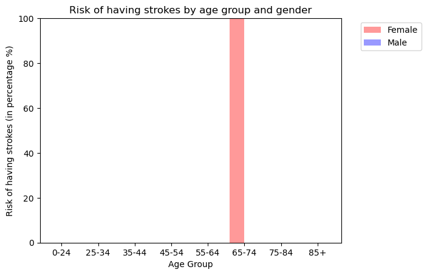

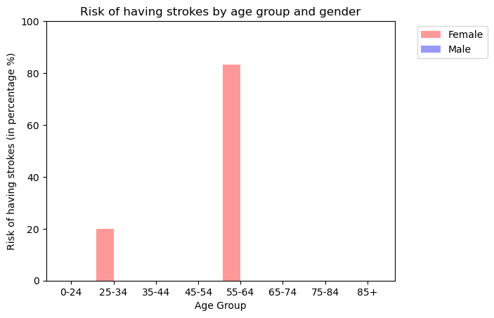

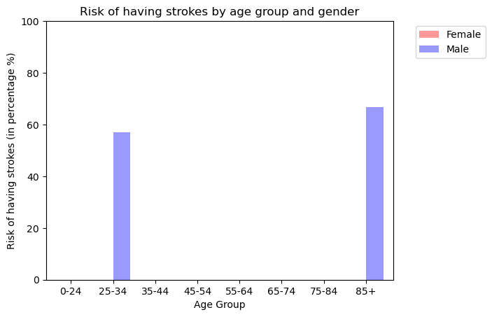

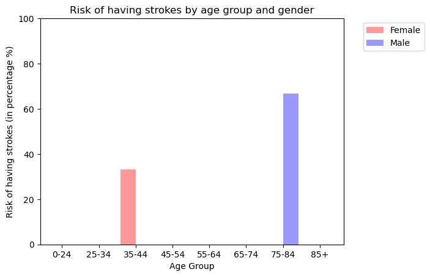

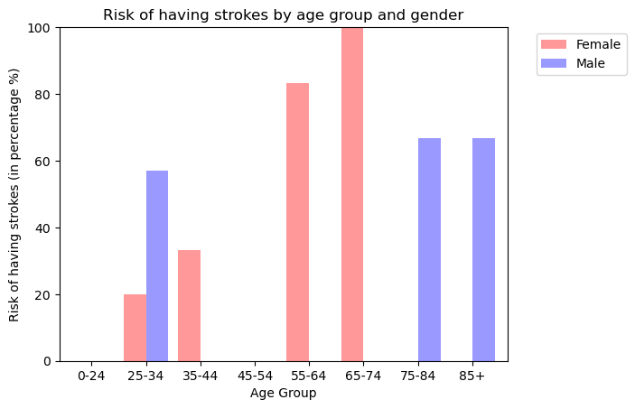

```
7 of 7 tests passed
7 of 7 tests passed
2 of 2 tests passed
2 of 2 tests passed
```

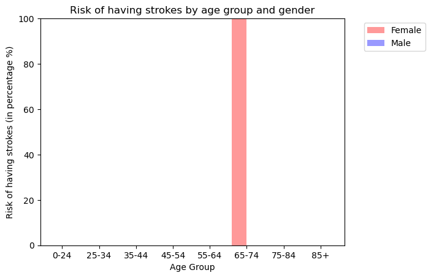

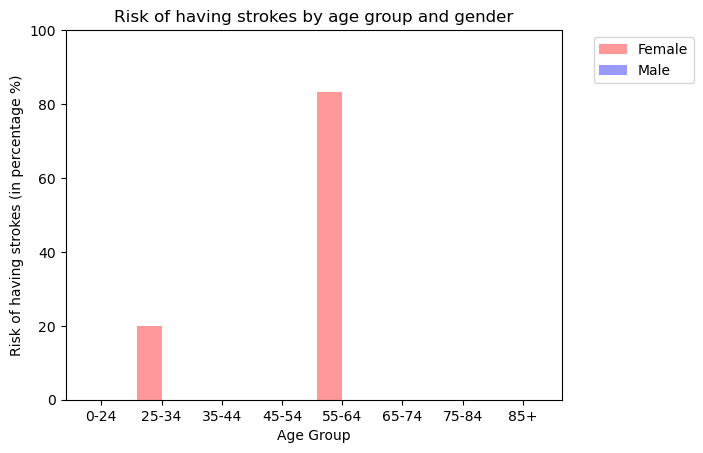

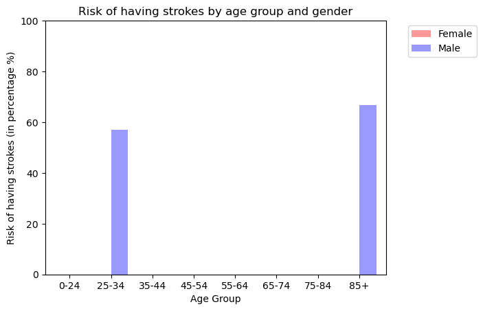

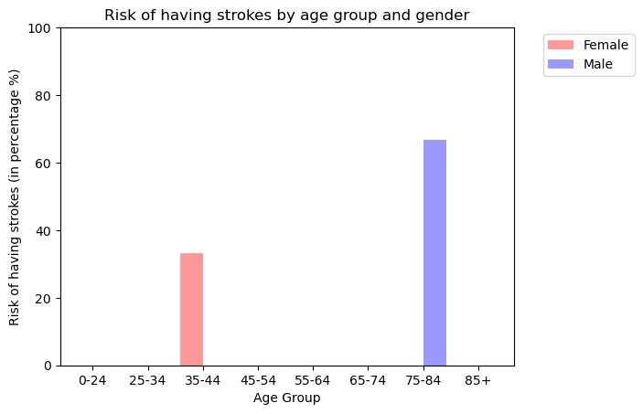

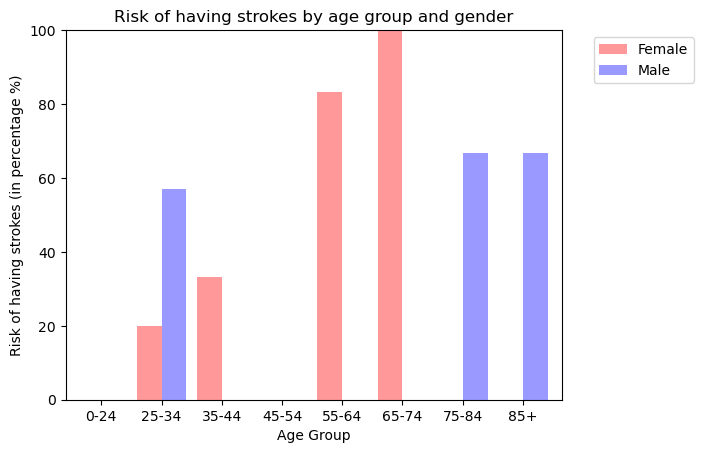

```
7 of 7 tests passed
7 of 7 tests passed
9 of 9 tests passed
10 of 10 tests passed
8 of 8 tests passed
7 of 7 tests passed
4 of 4 tests passed
7 of 7 tests passed
5 of 5 tests passed
7 of 7 tests passed
5 of 5 tests passed
6 of 6 tests passed
6 of 6 tests passed
5 of 5 tests passed
```

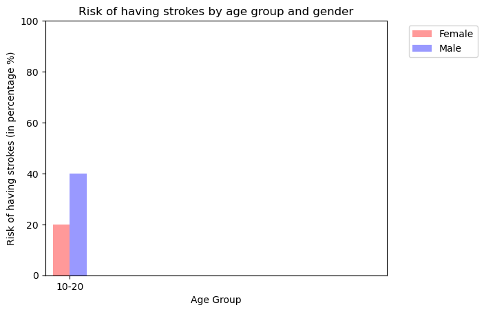

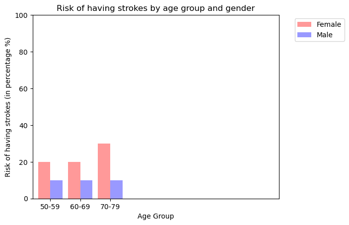

```
2 of 2 tests passed
3 of 3 tests passed
```

```python
summary()

start_testing()

# examples and tests for produce_num_sequence function
expect(produce_num_sequence([], 5, 10), [])
expect(produce_num_sequence([1, 10, 3], 5, 10), [5, 15, 25])
expect(produce_num_sequence([1, 10, 3], 0.5, 3.5), [0.5, 4.0, 7.5])

summary()
```

### Final Graph/Chart

Now that everything is working, you **must** call `main` on the intended information source in order to display the final graph/chart:

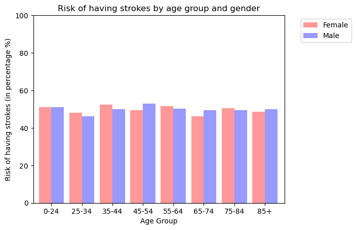

```python
main("stroke_prediction_dataset.csv")
```

```python
# Be sure to select ALL THE FILES YOU NEED (including csv's)
# when you submit. As usual, you cannot edit this cell.
# Instead, run this cell to start the submission process.
from cs103 import submit

COURSE = 123409
ASSIGNMENT = 1615244 # Final submission

submit(COURSE, ASSIGNMENT)

# If your submission fails, SUBMIT by downloading your files and uploading them
# to Canvas. You can learn how on the page "How to submit your Jupyter notebook"
# on our Canvas site.
```

# Please double check your submission on Canvas to ensure that the right files (Jupyter file + CSVs) have been submitted and that the files do not contain unexpected errors.

**You should always check your submission on Canvas. It is your responsibility to ensure that the correct file has been submitted for grading.** Regrade or accomodation requests using reasoning such as "I didn't realize I submitted the wrong file"/"I didn't realize the submission didn't work"/"I didn't realize I didn't save before submitting so some of my work is missing" will not be considered.